# Janette’s Data Sandbox

Janette Avelar

3/25/2022

# Cycle 1 (4.8.22)

Guiding questions/tasks & format:  
1. What are the frequencies of core practices?  
- table  
2. How long have schools been implementing each core practice?  
- table or stacked bar chart  
3. What are the frequencies of all practices?  
- table

Task 1: Frequencies

*Core practices identified as “Your Most Important Practices” with up to 5 selected.*

## What are the frequencies of core practices?

|  | Core Practice | Less than a year | 1-2 years | 3-4 years | 5+ years | Total | Frequency |
| --- | --- | --- | --- | --- | --- | --- | --- |
| 1 | assessments for social-emotional skills | 0 | 2 | 1 | 2 | 5 | 0.62% |
| 2 | students as co-leaders | 1 | 2 | 6 | 8 | 17 | 2.12% |
| 3 | teachers as co-leaders | 0 | 0 | 5 | 12 | 17 | 2.12% |
| 4 | assessments for deeper learning | 0 | 1 | 3 | 7 | 11 | 1.37% |
| 5 | flexible staffing &amp; alternative teaching roles | 1 | 0 | 3 | 5 | 9 | 1.12% |
| 6 | interdisciplinary | 1 | 1 | 5 | 18 | 25 | 3.12% |
| 7 | makerspace | 1 | 2 | 1 | 4 | 8 | 1% |
| 8 | peer to peer support | 1 | 0 | 0 | 1 | 2 | 0.25% |
| 9 | place-based learning | 2 | 1 | 6 | 6 | 15 | 1.87% |
| 10 | portfolios and public exhibitions of student work | 0 | 1 | 3 | 18 | 22 | 2.75% |

[output cut: 62 more lines]

## What are the frequencies of top 10 core practices?

|  | Core Practice | Less than a year | 1-2 years | 3-4 years | 5+ years | Total | Frequency |
| --- | --- | --- | --- | --- | --- | --- | --- |
| 1 | portfolios and public exhibitions of student work | 0 | 1 | 3 | 18 | 22 | 2.75% |
| 2 | culturally responsive practices | 2 | 5 | 4 | 11 | 22 | 2.75% |
| 3 | interdisciplinary | 1 | 1 | 5 | 18 | 25 | 3.12% |
| 4 | social justice focus | 1 | 1 | 7 | 17 | 26 | 3.25% |
| 5 | design to meet needs of students who have been marginalized | 2 | 5 | 7 | 17 | 31 | 3.87% |
| 6 | real-world problem solving | 0 | 4 | 9 | 21 | 34 | 4.24% |
| 7 | competency/mastery-based education | 3 | 9 | 9 | 20 | 41 | 5.12% |
| 8 | restorative practices | 1 | 7 | 14 | 19 | 41 | 5.12% |
| 9 | SEL integration school-wide | 2 | 8 | 6 | 26 | 42 | 5.24% |
| 10 | project-based learning | 1 | 4 | 12 | 33 | 50 | 6.24% |

## How long have schools been implementing each core practice?

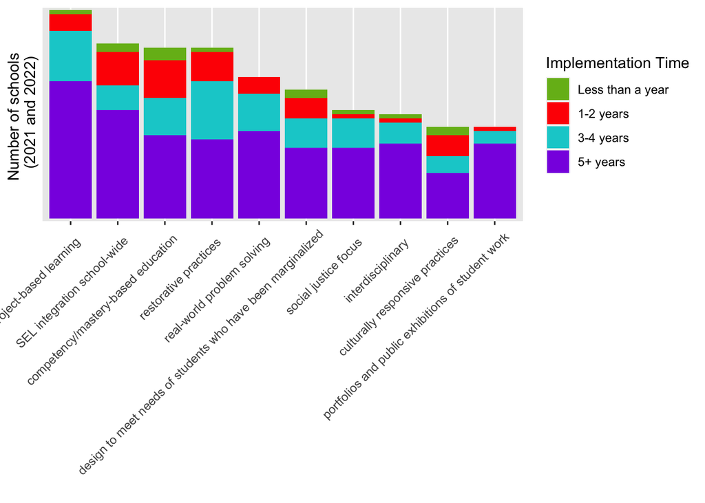

## What are the frequencies of all practices?

|  | Practice Selected | Total | Frequency |
| --- | --- | --- | --- |
| 1 | assessments for social-emotional skills | 113 | 1.81% |
| 2 | students as co-leaders | 78 | 1.25% |
| 3 | teachers as co-leaders | 120 | 1.92% |
| 4 | assessments for deeper learning | 124 | 1.99% |
| 5 | flexible staffing &amp; alternative teaching roles | 106 | 1.7% |
| 6 | interdisciplinary | 125 | 2% |
| 7 | makerspace | 66 | 1.06% |
| 8 | peer to peer support | 91 | 1.46% |
| 9 | place-based learning | 80 | 1.28% |
| 10 | portfolios and public exhibitions of student work | 115 | 1.84% |

[output cut: 62 more lines]

## What are the frequencies for the top 10 of all practices?

|  | Practice Selected | Total | Frequency |
| --- | --- | --- | --- |
| 1 | interdisciplinary | 125 | 2% |
| 2 | project-based learning | 130 | 2.08% |
| 3 | opportunities_mastery | 129 | 2.07% |
| 4 | design to meet needs of students who have been marginalized | 128 | 2.05% |
| 5 | assessments for deeper learning | 124 | 1.99% |
| 6 | real-world problem solving | 123 | 1.97% |
| 7 | culturally responsive practices | 122 | 1.95% |
| 8 | SEL integration school-wide | 122 | 1.95% |
| 9 | teachers as co-leaders | 120 | 1.92% |
| 10 | community and business partnerships | 119 | 1.91% |

[output cut: 1 more lines]

# Cycle 2 (4.22.22)

To Do:  
* Create new locale variable from NCES and self-reported data  
* Collapse school type variables  
* Less important: Pivot practices (double check sums are correct)  
* Collapse leader race variable (will need if/else for bi/multiracial variable)  
* Fill meaningful data (yes/no/NA)

## Data Cleaning

### Locale

Created a new variable `locale` to indicate whether a school is urban, rural, or suburban. This variable merges NCES and self-reported data, with NCES data taking precedence in instances where we had information from both sources. There is 1 instance of `NA` where neither NCES or self-reported data were recorded. An additional 3 instances were coded as `NA` (Iowa Big, The Forest Schools, & Link Learning) indicating multi-coded schools which should be excluded from locale-specific analysis.

*Status:* Complete

### School Type

School type was previously divided into 10 columns representing the following:  
* district  
* charter  
* independent  
* sws  
* virtual  
* microschool  
* homeschool  
* hub  
* other  
* text description for `other`

Values representing yes and no have been condensed into a single column named `school_type` specifying one of the values from the list above.

*Status:* In progress - a few instances of `other` and another item from list chosen. I need to know what to do in instances of multi-coding in order to proceed. Also need to know if `other` text should be its own value, or if a value of `other` with an additional column for text is preferable.

### School Leader Racial Identity

School leaders filling out the survey were asked to report how they identify racially. This variable was previously coded across 9 columns, with the following values:  
* AIAN  
* Asian  
* Black  
* Hispanic  
* NHPI  
* White  
* Self describe option  
* Text for `self describe`  
* No Response (which I assume is prefer not to respond)

Values were coded as either `yes` or `no` which has been collapsed into a single column `confidential_leader_race` with a value filled in according to the list above. An additional value, `Biracial` has been added for leaders who identified as more than one race (there were no instances with more than 2 races reported).

The new values include:  
* White  
* Biracial  
* Hispanic  
* Asian  
* No Response  
* NA (1 missing observation)  
* Xicana Indigena (1 observation)  
* Middle Eastern (1 observation)  
* AIAN

Note that NHPI was dropped because there were no coded NHPI cases. Self-reported text was used, but I can change this to “Other” or to any other value desired if needed.

*Status:* Complete – variable is a factor with previously listed values.

### Private School NCES Data

The NCES data merged with our Canopy dataset includes counts for each grade level within private schools. Each variable (listed below) has been recoded so that any values are converted to “Yes”, “No”, “Not Reported”, or “NA” as applicable. (Note NAs were used when cells were completely empty. NA is **not** the same as Not Reported.)

Variables of interest:  
* `nces_grades_pre_k`  
* `nces_grades_kindergarten`  
* `nces_grades_1st`  
* `nces_grades_2nd`  
* `nces_grades_3rd`  
* `nces_grades_4th`  
* `nces_grades_5th`  
* `nces_grades_6th`  
* `nces_grades_7th`  
* `nces_grades_8th`  
* `nces_grades_9th`  
* `nces_grades_10th`  
* `nces_grades_11th`  
* `nces_grades_12th`  
* `nces_grades_13th`

I did not create a new variable designating grade levels offered (e.g., elementary, middle, high, mixed elementary/jr high, mixed jr/sr high, etc.) but can do so if needed.

Can also recode so NA is the same as Not Reported if needed.

*Status:* Complete.

# Cycle 3 (5.6.22)

To Do:  
* Wrap up locale variable  
* Wrap up standardizing grade levels in NCES data  
* Convert `nces_race_values` to % (denom = `nces_total_enrollment`)  
* Merge self-reported and NCES data on student demographics (`self_reported_race_` & `nces_race_variables`)  
* Merge self-reported and NCES data on grade levels  
* Create new variables for elementary, middle, and high (pull out multiples in list)  
### `Locale` Variable

**Task:** Merge self-reported and NCES data on locale  
**Status:** Complete (see Cycle 2 for details)

### Standardize NCES grade levels

**Task:** Ensure independent schools’ NCES grade level data matches other schools.  
**Status:** Complete (see Cycle 2 for details)  
### Convert `nces_race_*` to percentages

The following variables now represent percentages (group/`nces_total_enrollment`) rather than counts:  
* `nces_race_aian`  
* `nces_race_asian`  
* `nces_race_black`  
* `nces_race_hispanic`  
* `nces_race_nhpi`  
* `nces_race_white`  
* `nces_race_multiple`

Rather than calculating, I imported the updated data that had percentages in each of these columns and merged them with the dataset.

**Status:** Complete

### Merge `self_reported_*` and `nces_race_*`

Columns with self-reported and NCES data documenting student racial demographics merged into the following single columns:  
* `aian_percent`  
* `asian_percent`  
* `black_percent`  
* `hispanic_percent`  
* `nhpi_percent`  
* `white_percent`  
* `multiple_percent`

Note all columns were changed to numeric type for easier future analysis.

The data includes 35 instances of `NA` for the following 5 schools (5 schools x 7 racial groups = 35), meaning *both* NCES and self-reported data were missing:  
* Aspen Academy (row 3)  
* CodeRVA Regional High School (row 9)  
* Lead Innovation Studio (row 67)  
* Liberty Academy (row 109)  
* CLK Engage At CLK Elementary School (row 124)

**Status:** Complete

### Merge grade level data

Columns with self-reported and NCES grade level data were merged into the following columns:  
* `grades_pre_k`  
* `grades_kindergarten`  
* `grades_1st`  
* `grades_2nd`  
* `grades_3rd`  
* `grades_4th`  
* `grades_5th`  
* `grades_6th`  
* `grades_7th`  
* `grades_8th` * `grades_9th`  
* `grades_10th`  
* `grades_11th`  
* `grades_12th`  
* `grades_past_12th`  
* `grades_other`

The dataset includes 4 schools that indicated `other`. `Yes`/`No` values were modified so that the text starts with “Yes_” to make manipulation easier when using `starts_with()` but I can change this if that does not make sense.  
Schools include:  
* Utah Schools For The Deaf (row 157)  
+ `Yes_Birth - 3 years of age` * One Stone (row 147)  
+ `Yes_Our high school aged students provide year round educational opportunities to Yesst-7th grade students in the region. These range from STEM camps for 3-4th graders to entrepreneur workshops for middle schoolers.` * Link Learning (row 144)  
+ `Yes_adults up to 22 years old` * The Forest Schools (row 140)  
+ `Yes_Our Institute contracts with educators and leaders`

*Status:* Complete

### Create new `school_grade_type` variable

Create new variables for school type based on grades offered as follows:  
* `prek` = schools including prek * `elementary` = schools with any K-5 grades  
* `middle` = schools with any 6-8 grades  
* `high` = schools with any 9-12 grades  
* `other` = schools with past 12th grades and/or who indicated other

Many schools (N = 90) fell into multiple categories. These schools can be found in the `multi-coded_grades.csv` file in `Data` folder, or on GDrive.

*Status:* In Progress - Variable is created, but multi-coded schools need to be addressed.

### Look through new variables

*Status:* In progress

My next step is to look through the variables created/data exported and do some restructuring/moving around. Columns were shifted in the cleaning process so they just need to get back where they belong.

Also just generally going back through to check everything is looking how it should and will manually recode anything that was overlooked or needs relabeling.